# Principle Component Analysis

Natalie Huerta

2023-04-19

```r
rm(list=ls(all=TRUE))
```

# 1 Introduction

Reading comprehension has been shown to predict academic achievement in school as well success later in life (Locasio et al., 2010; Rabiner et al., 2016). As a result, much research has been devoted to understanding reading comprehension and its underlying mechanisms. The Simple View of Reading (SVR; Gough & Tunmer, 1986) posited that reading comprehension was the product of word reading and language comprehension. While the simple view is widely accepted, additions to the model have been proposed (Duke & Cartwright, 2021; Cutting et al., 2015) to include other cognitive or behavioral components such as executive function. Executive function is a set of processes that regulate cognitive, behavioral, and emotional tasks and have been shown to contribute to reading outcomes (Aboud et al., 2018; Cutting et al., 2015). This data analysis aimed to use the machine learning methods of 10-fold cross validation and feature selection to produce a model predicting reading comprehension. The goal was to determine if reading comprehension was best predicted by decoding and language skills alone, or if executive function was a necessary addition to the model.

**Research Question**: 1. Can variables related to decoding, language comprehension, executive function be reduced into component scores? 2. If so, are the resulting components predictive of reading comprehension in 8–12-year-old readers?

# 2 Data

This data was collected in the Education Brain and Science Lab at Vanderbilt as part of a study investigating the cognitive and neurological underpinnings of reading comprehension in 8–12-year-olds (n = 274). The data reflect a portion of the behavioral and survey data collected.

## 2.1 The Variables

The variables of interest for the analyses in this paper were:

- **Reading Comprehension**: Reading comprehension is the ability to show an understanding of written text and was measured by the Woodcock-Johnson III (WJ-III) Passage Comprehension sub test. Reading comprehension was the outcome variable in the analysis.
- **Decoding**: Decoding is the ability to read words and nonsense words accurately. Measures used that are thought of as measures of decoding included:
  - Woodcock-Johnson III
    - Word Attack measured students’ ability to read progressively challenging nonsense words in isolation.
    - Letter Word ID measured students’ ability to name letters and read progressively challenging real words in isolation.
  - Test of Word Reading Efficiency (TOWRE)
    - The Phonemic Decoding sub test asked student to read progressively challenging nonsense words in isolation.
    - The Sight Word sub test asked students to read progresisvely challenging regular words.
- **Language Comprehension**: Language comprehension as talked about in the Simple View of Reading is the ability to understand language and includes listening comprehension skills, vocabulary, and other verbal abilities. Measures used that are thought of as measures of language included:
  - Wechsler Abbreviated Scale of Intelligence (WASI)
    - Verbal IQ was a composite score made up of the Vocabulary and Similarities subtests.
    - WASI_Vocabulary asked students to name items in pictures and define terms presented orally.
  - Test of Language Competence- Expanded (TLC-E):
    - The Listening Comprehension sub test asked students to make inferences based on causal relationships introduced in short passages read aloud.
    - The Ambiguous Sentences sub test asked students to recognize and determine alternate meanings of words based on the context provided.
  - Test of Word Knowledge (TOWK):
    - The Expressive Vocabulary sub test asked students to provide names for pictures provided.
    - The Receptive Vocabulary sub test asked students to point to the picture, out of four choices, that matched the word given.
    - The Synonyms and Figurative Language sub test asked students to identify words that are synonyms and provide explanations for figurative language.
  - Test of Morphological Structure
    - The Morphological Derivation sub test provided students with a morphological base form and then asked students to fill in the blank of a sentence using the morphologically derived word.
    - The Morphological Decomposition sub test provided students with a morphologically derived stem and then a sentence context that required them to fill in the blank with the morphological base form.
    - The Morphological Relatedness subtest asked students to idntify words that were related to one another.
  - Woodcock-Johnson
  - The Analysis-Synthesis sub test asked students to draw conclusions from stated situations and is thought of as a measure of deductive or algorithmic reasoning.
- **Executive Function (EF)**: Executive function is a set of mental processes that regulate cognition, emotion, and behavior. Measures used that are thought of as measures of executive function included:
  - Delis-Kaplan Executive Function System (D-KEFS).
    - The Card Sorting composite involved activities where students had to create, identify and shift between card categories. It measured cognitive flexibility and inhibition, two generally agreed upon major elements of executive function.
    - The Twenty Questions sub test asked students to ask yes or no questions to guess an object and assessed abstract reasonoing and cognitive felxibility.
  - Weschler Intelligence Scale for Children IV (WISC-IV)
    - The Elithorn Mazes sub test asked students to complete a series of progressively challenging mazes, measuring planning and inhibition.
    - The Spatial Span sub test asked students to reproduce a sequence of tapped blocks, measuring working memory.
  - Behavior Rating Inventory of Executive Function (BRIEF)
    - The BRIEF was a rating scale completed by a parent that provided ratings on cognitive, emotional, and behavioral regulation. The score used in the analysis was the Global Executive index, which was a composite score of all three areas of EF.

## 2.2 Wrangle Data

The data was wrangled by calling in the file and selecting the outcome variable and predictor variables of interest. These were predictors related to decoding, language comprehension and executive function. All blanks and NaN were replaced with NA. Then the tibble was filtered to include only observations without NA in any of the predictors or the outcome variable. This resulted in 223 observations of 21 variables. The outcome variable was relocated to be the first column in the tibble, and variables were renamed for readability and easier visualization in later steps. The tibble structure was checked and all variables were characters so they were all changed to numeric.

```r
library(tidyverse)
RCV_pca <- read_csv("RCV_Dim_Red.csv") %>%
  select(-one_of("tq_tqa_ss", "participant_id","baseline_wpm_stdev", "vocab_total_correct_percent","baseline_mean_sec", "decoding_total_correct_percent", "gmrt4_ess")) %>% #-one_of means that it selected everything in the file except the ones listed
   mutate(across(everything(), ~ifelse(.=="", NA, as.character(.))))%>% #convert empty cells to NA
   mutate(across(everything(), ~ifelse(.=="NaN", NA, as.character(.))))%>% #had some weird NaN's in a few columns, so this turned them into NA's
  filter(across(.cols = everything(),.fns = ~ !is.na(.))) %>%  #Remove any observations with an NA in the outcome variable or predictor variables
   rename(Verbal_IQ = iq_verbal, WASI_Vocabulary = iqvts, WJ_Reading_Comprehension = wjiii_comp_ss, Letter_Word_ID = lw_id_ss, Word_Attack = wa_ss, Ambiguous_Sentences = tlc_as_ss, Inferences = tlc_lc_ss, Receptive_Vocabulary = towk_rv_ss, Expressive_Vocabulary = towk_ev_ss, Synonyms = towk_s_ss, EF_Card_Sorting = sorting_cd_comp, EF_Mazes = wiscepmtss, EF_BRIEF = bpgei, Synthesis = as_ss, TOWRE_Decoding = towreswess, TOWRE_Sight_Words = towrepdess, Morph_Derivation = tms_d, Morph_Decomposition = tms_dc, Morph_Relatedness = mrt, Spatial_Span = spatial_span_ss, Twenty_Questions = tq_was_ss) %>% #change names of variables
   relocate(WJ_Reading_Comprehension, .before = EF_BRIEF)#move outcome variable to be listed first in the tibble so it is easier to see in correlation visualizations later
str(RCV_pca) #check structure for all numeric
```

```
## tibble [223 × 21] (S3: tbl_df/tbl/data.frame)
##  $ WJ_Reading_Comprehension: chr [1:223] "95" "88" "58" "88" ...
##  $ EF_BRIEF                : chr [1:223] "76" "49" "50" "50" ...
##  $ WASI_Vocabulary         : chr [1:223] "44" "59" "37" "48" ...
##  $ Verbal_IQ               : chr [1:223] "99" "105" "80" "93" ...
##  $ Letter_Word_ID          : chr [1:223] "94" "104" "61" "98" ...
##  $ Word_Attack             : chr [1:223] "86" "89" "68" "98" ...
##  $ Synthesis               : chr [1:223] "103" "86" "85" "90" ...
##  $ TOWRE_Decoding          : chr [1:223] "97" "97" "70" "114" ...
##  $ TOWRE_Sight_Words       : chr [1:223] "77" "94" "67" "117" ...
##  $ Expressive_Vocabulary   : chr [1:223] "7" "8" "3" "7" ...
##  $ Receptive_Vocabulary    : chr [1:223] "12" "12" "4" "12" ...
##  $ Synonyms                : chr [1:223] "7" "13" "3" "10" ...
##  $ Ambiguous_Sentences     : chr [1:223] "6" "8" "5" "10" ...
##  $ Inferences              : chr [1:223] "10" "11" "7" "7" ...
##  $ Morph_Derivation        : chr [1:223] "21" "24" "3" "18" ...
##  $ Morph_Decomposition     : chr [1:223] "23" "24" "8" "20" ...
##  $ Morph_Relatedness       : chr [1:223] "10" "9" "8" "5" ...
##  $ Spatial_Span            : chr [1:223] "12" "14" "9" "14" ...
##  $ Twenty_Questions        : chr [1:223] "12" "13" "8" "13" ...
##  $ EF_Mazes                : chr [1:223] "13" "7" "8" "15" ...
##  $ EF_Card_Sorting         : chr [1:223] "9" "8" "7" "10" ...
```

```r
#everything is a character, so make numeric
 RCV_pca_2<- RCV_pca %>%
   mutate_at(c(1:21),as.numeric) #if character in columns 1:21, change to numeric

   str(RCV_pca_2) #all numeric so now all good
```

```
## tibble [223 × 21] (S3: tbl_df/tbl/data.frame)
##  $ WJ_Reading_Comprehension: num [1:223] 95 88 58 88 107 99 102 89 105 80 ...
##  $ EF_BRIEF                : num [1:223] 76 49 50 50 39 72 63 43 62 76 ...
##  $ WASI_Vocabulary         : num [1:223] 44 59 37 48 72 54 56 61 65 47 ...
##  $ Verbal_IQ               : num [1:223] 99 105 80 93 134 110 102 110 112 98 ...
##  $ Letter_Word_ID          : num [1:223] 94 104 61 98 100 92 98 87 117 80 ...
##  $ Word_Attack             : num [1:223] 86 89 68 98 88 84 96 84 104 89 ...
##  $ Synthesis               : num [1:223] 103 86 85 90 102 124 123 92 106 89 ...
##  $ TOWRE_Decoding          : num [1:223] 97 97 70 114 107 89 107 87 110 80 ...
##  $ TOWRE_Sight_Words       : num [1:223] 77 94 67 117 92 67 90 82 120 75 ...
##  $ Expressive_Vocabulary   : num [1:223] 7 8 3 7 12 10 6 7 11 6 ...
##  $ Receptive_Vocabulary    : num [1:223] 12 12 4 12 14 10 10 11 14 11 ...
##  $ Synonyms                : num [1:223] 7 13 3 10 14 11 11 10 14 11 ...
##  $ Ambiguous_Sentences     : num [1:223] 6 8 5 10 12 13 7 6 11 9 ...
##  $ Inferences              : num [1:223] 10 11 7 7 13 8 6 12 7 4 ...
##  $ Morph_Derivation        : num [1:223] 21 24 3 18 22 23 19 19 24 16 ...
##  $ Morph_Decomposition     : num [1:223] 23 24 8 20 27 25 27 25 26 24 ...
##  $ Morph_Relatedness       : num [1:223] 10 9 8 5 9 10 10 10 9 9 ...
##  $ Spatial_Span            : num [1:223] 12 14 9 14 16 15 10 7 17 8 ...
##  $ Twenty_Questions        : num [1:223] 12 13 8 13 8 11 8 12 13 9 ...
##  $ EF_Mazes                : num [1:223] 13 7 8 15 13 15 11 11 10 8 ...
##  $ EF_Card_Sorting         : num [1:223] 9 8 7 10 14 13 11 12 12 7 ...
```

# 3 Principle Component Analysis

The goal of the principle component analysis(PCA) was to determine if variables related to decoding, language comprehension, executive function could be reduced into components rather than individual measures. Running a PCA helped eliminate excess variables that could have resulted in overfitting the model or increased the liklihood of multicollinearity. The steps used are outliined below with additional details located with each step.

## 3.1 Steps in running a PCA

1. Check for multicollinearity between variables (r > .899)
2. Scale variables
3. Visualize the data
4. Bartlett’s test including sample size
5. KMO on the data (look for variables below .5 and remove)
6. Baseline PCA to check scree plot, SS loadings above 1, and normal distribution of variables
7. Check that residuals are normally distributed
8. Run PCA with selected number of components based on interpretation of scree plot and SS loadings
9. Interpret and name components
10. Send component scores to csv

## 3.2 Correlations for Strong Multicollinearity

Correlations of all variables were run to check for overly strong correlations. It was assumed that there would be high correlations given that many of these vairbales were supposed to be measuring very similar constructs. Variables that were correlated above .899 were removed because that indicated that the variables were essentially the same. The WASI Vocabulary subtest and Verbal IQ were correlated above .899, so WASI Vocab was removed. Woodcock_Johnson_Comprehension was also removed because it was the singular outcome variable and did not need to be included in the rest of the PCA steps. Correlations were run again to double check that they all were below .899.

```r
corr_RCV_pca <- cor(RCV_pca_2)#get correlations of whole tibble

corr_RCV_pca # take a look
```

```
##                          WJ_Reading_Comprehension   EF_BRIEF WASI_Vocabulary
## WJ_Reading_Comprehension                1.0000000 -0.2719028       0.7059541
## EF_BRIEF                               -0.2719028  1.0000000      -0.2880499
## WASI_Vocabulary                         0.7059541 -0.2880499       1.0000000
## Verbal_IQ                               0.7136477 -0.2992898       0.9344227
## Letter_Word_ID                          0.7504117 -0.2590302       0.7073323
## Word_Attack                             0.6074724 -0.3363919       0.5456827
## Synthesis                               0.5223767 -0.2288900       0.4977027
## TOWRE_Decoding                          0.5933505 -0.2323898       0.5885527
## TOWRE_Sight_Words                       0.6194955 -0.2937239       0.5964230
## Expressive_Vocabulary                   0.6279017 -0.2117757       0.6642967
## Receptive_Vocabulary                    0.6556086 -0.2561647       0.7361386
## Synonyms                                0.6367609 -0.2723686       0.7339688
## Ambiguous_Sentences                     0.6400327 -0.1927884       0.6282249
## Inferences                              0.4547481 -0.1368573       0.4535397
## Morph_Derivation                        0.6396999 -0.1905987       0.6308318
## Morph_Decomposition                     0.6207222 -0.2062418       0.5666442
## Morph_Relatedness                       0.3461816 -0.1323757       0.3235472
## Spatial_Span                            0.2375101 -0.2229837       0.3351500
## Twenty_Questions                        0.3602434 -0.2162750       0.3814711
## EF_Mazes                                0.3228639 -0.1364502       0.2932921
## EF_Card_Sorting                         0.5362428 -0.2850221       0.6056708
##                           Verbal_IQ Letter_Word_ID Word_Attack  Synthesis
## WJ_Reading_Comprehension  0.7136477      0.7504117   0.6074724  0.5223767
## EF_BRIEF                 -0.2992898     -0.2590302  -0.3363919 -0.2288900
## WASI_Vocabulary           0.9344227      0.7073323   0.5456827  0.4977027
## Verbal_IQ                 1.0000000      0.7025899   0.5496885  0.5535885
## Letter_Word_ID            0.7025899      1.0000000   0.8011914  0.4453014
## Word_Attack               0.5496885      0.8011914   1.0000000  0.3731912
## Synthesis                 0.5535885      0.4453014   0.3731912  1.0000000
## TOWRE_Decoding            0.5594664      0.6894314   0.5996130  0.3527144
## TOWRE_Sight_Words         0.5591204      0.8050968   0.7989655  0.3396926
## Expressive_Vocabulary     0.6950999      0.6560470   0.4583474  0.4114852
## Receptive_Vocabulary      0.7426316      0.6541013   0.4932843  0.4413452
## Synonyms                  0.7166767      0.6734981   0.5076059  0.5014640
## Ambiguous_Sentences       0.6487824      0.6168792   0.4908976  0.4495283
## Inferences                0.4830061      0.4102838   0.2486198  0.3918803
## Morph_Derivation          0.6120820      0.6452785   0.5300756  0.4597910
## Morph_Decomposition       0.5451079      0.6418205   0.5344007  0.4229778
## Morph_Relatedness         0.3724917      0.3567973   0.2992648  0.3743579
```

[output cut: 99 more lines]

```
## Synthesis                 0.2373111       0.4765551
## TOWRE_Decoding            0.3148053       0.3536600
## TOWRE_Sight_Words         0.2747513       0.3591668
## Expressive_Vocabulary     0.2477574       0.4749006
## Receptive_Vocabulary      0.3172465       0.5357384
## Synonyms                  0.2436425       0.5165404
## Ambiguous_Sentences       0.2102671       0.5146649
## Inferences                0.1397797       0.3956693
## Morph_Derivation          0.2351038       0.4723557
## Morph_Decomposition       0.2558589       0.4072540
## Morph_Relatedness         0.1160000       0.2725731
## Spatial_Span              0.4563724       0.3081691
## Twenty_Questions          0.2185955       0.4069012
## EF_Mazes                  1.0000000       0.3344080
## EF_Card_Sorting           0.3344080       1.0000000
```

```r
write.csv(corr_RCV_pca, "corr_matrix_for_RCV_pca.csv") #send to a csv file to check out more easily

RCV_pca_3<- RCV_pca_2 %>%
  select(-1,-3) # remove WASI Vocab and WJ_Comp which are column 1 and 3 in tibble
str(RCV_pca_3)
```

```
## tibble [223 × 19] (S3: tbl_df/tbl/data.frame)
##  $ EF_BRIEF             : num [1:223] 76 49 50 50 39 72 63 43 62 76 ...
##  $ Verbal_IQ            : num [1:223] 99 105 80 93 134 110 102 110 112 98 ...
##  $ Letter_Word_ID       : num [1:223] 94 104 61 98 100 92 98 87 117 80 ...
##  $ Word_Attack          : num [1:223] 86 89 68 98 88 84 96 84 104 89 ...
##  $ Synthesis            : num [1:223] 103 86 85 90 102 124 123 92 106 89 ...
##  $ TOWRE_Decoding       : num [1:223] 97 97 70 114 107 89 107 87 110 80 ...
##  $ TOWRE_Sight_Words    : num [1:223] 77 94 67 117 92 67 90 82 120 75 ...
##  $ Expressive_Vocabulary: num [1:223] 7 8 3 7 12 10 6 7 11 6 ...
##  $ Receptive_Vocabulary : num [1:223] 12 12 4 12 14 10 10 11 14 11 ...
##  $ Synonyms             : num [1:223] 7 13 3 10 14 11 11 10 14 11 ...
##  $ Ambiguous_Sentences  : num [1:223] 6 8 5 10 12 13 7 6 11 9 ...
##  $ Inferences           : num [1:223] 10 11 7 7 13 8 6 12 7 4 ...
##  $ Morph_Derivation     : num [1:223] 21 24 3 18 22 23 19 19 24 16 ...
##  $ Morph_Decomposition  : num [1:223] 23 24 8 20 27 25 27 25 26 24 ...
##  $ Morph_Relatedness    : num [1:223] 10 9 8 5 9 10 10 10 9 9 ...
##  $ Spatial_Span         : num [1:223] 12 14 9 14 16 15 10 7 17 8 ...
##  $ Twenty_Questions     : num [1:223] 12 13 8 13 8 11 8 12 13 9 ...
##  $ EF_Mazes             : num [1:223] 13 7 8 15 13 15 11 11 10 8 ...
##  $ EF_Card_Sorting      : num [1:223] 9 8 7 10 14 13 11 12 12 7 ...
```

```r
corr_RCV_pca_2 <- cor(RCV_pca_3)#checking correlations again

corr_RCV_pca_2
```

```
##                         EF_BRIEF  Verbal_IQ Letter_Word_ID Word_Attack
## EF_BRIEF               1.0000000 -0.2992898     -0.2590302  -0.3363919
## Verbal_IQ             -0.2992898  1.0000000      0.7025899   0.5496885
## Letter_Word_ID        -0.2590302  0.7025899      1.0000000   0.8011914
## Word_Attack           -0.3363919  0.5496885      0.8011914   1.0000000
## Synthesis             -0.2288900  0.5535885      0.4453014   0.3731912
## TOWRE_Decoding        -0.2323898  0.5594664      0.6894314   0.5996130
## TOWRE_Sight_Words     -0.2937239  0.5591204      0.8050968   0.7989655
## Expressive_Vocabulary -0.2117757  0.6950999      0.6560470   0.4583474
## Receptive_Vocabulary  -0.2561647  0.7426316      0.6541013   0.4932843
## Synonyms              -0.2723686  0.7166767      0.6734981   0.5076059
## Ambiguous_Sentences   -0.1927884  0.6487824      0.6168792   0.4908976
## Inferences            -0.1368573  0.4830061      0.4102838   0.2486198
## Morph_Derivation      -0.1905987  0.6120820      0.6452785   0.5300756
## Morph_Decomposition   -0.2062418  0.5451079      0.6418205   0.5344007
## Morph_Relatedness     -0.1323757  0.3724917      0.3567973   0.2992648
## Spatial_Span          -0.2229837  0.2757868      0.2070276   0.2645654
## Twenty_Questions      -0.2162750  0.3817546      0.2744884   0.2147188
## EF_Mazes              -0.1364502  0.2450718      0.2968161   0.3232089
## EF_Card_Sorting       -0.2850221  0.6226620      0.4836067   0.3467603
##                        Synthesis TOWRE_Decoding TOWRE_Sight_Words
## EF_BRIEF              -0.2288900     -0.2323898        -0.2937239
## Verbal_IQ              0.5535885      0.5594664         0.5591204
## Letter_Word_ID         0.4453014      0.6894314         0.8050968
## Word_Attack            0.3731912      0.5996130         0.7989655
## Synthesis              1.0000000      0.3527144         0.3396926
## TOWRE_Decoding         0.3527144      1.0000000         0.7810097
## TOWRE_Sight_Words      0.3396926      0.7810097         1.0000000
## Expressive_Vocabulary  0.4114852      0.4831084         0.4854923
## Receptive_Vocabulary   0.4413452      0.5758073         0.5658841
## Synonyms               0.5014640      0.5171480         0.5625499
## Ambiguous_Sentences    0.4495283      0.4969268         0.5264168
## Inferences             0.3918803      0.3526609         0.3209573
## Morph_Derivation       0.4597910      0.4948033         0.5194592
## Morph_Decomposition    0.4229778      0.5142935         0.5099931
## Morph_Relatedness      0.3743579      0.2190650         0.2298453
## Spatial_Span           0.2991399      0.2446354         0.2595245
## Twenty_Questions       0.4046115      0.2402840         0.2406381
## EF_Mazes               0.2373111      0.3148053         0.2747513
## EF_Card_Sorting        0.4765551      0.3536600         0.3591668
```

[output cut: 65 more lines]

```
## Synthesis                    0.4046115  0.2373111       0.4765551
## TOWRE_Decoding               0.2402840  0.3148053       0.3536600
## TOWRE_Sight_Words            0.2406381  0.2747513       0.3591668
## Expressive_Vocabulary        0.3270112  0.2477574       0.4749006
## Receptive_Vocabulary         0.3202864  0.3172465       0.5357384
## Synonyms                     0.3207350  0.2436425       0.5165404
## Ambiguous_Sentences          0.2754929  0.2102671       0.5146649
## Inferences                   0.3321818  0.1397797       0.3956693
## Morph_Derivation             0.2808625  0.2351038       0.4723557
## Morph_Decomposition          0.2926282  0.2558589       0.4072540
## Morph_Relatedness            0.2000700  0.1160000       0.2725731
## Spatial_Span                 0.1933362  0.4563724       0.3081691
## Twenty_Questions             1.0000000  0.2185955       0.4069012
## EF_Mazes                     0.2185955  1.0000000       0.3344080
## EF_Card_Sorting              0.4069012  0.3344080       1.0000000
```

```r
write.csv(corr_RCV_pca_2, "corr_matrix_for_RCV_pca.csv")#send to a csv file to check out
#all correlations below .899
```

## 3.3 Scaling Variables

All variables were scaled using psych. Scaling the varibales eliminated the concern that a variable would appear to explain more variance in the PCA just because it was measured on a large scale with larger variance. After scaling, descriptives were printed and checked to make sure means were all 0 and standard deviations were 1.

```r
library(psych) #library needed for scaling and getting descriptives
scaled_data_pca <- RCV_pca_3 %>% #create new scaled vairable tibble
  mutate_at(c(1:19), ~(scale(.) %>% as.vector)) #scale everything

str(scaled_data_pca)
```

```
## tibble [223 × 19] (S3: tbl_df/tbl/data.frame)
##  $ EF_BRIEF             : num [1:223] 2.107 -0.244 -0.157 -0.157 -1.114 ...
##  $ Verbal_IQ            : num [1:223] -0.669 -0.277 -1.91 -1.061 1.618 ...
##  $ Letter_Word_ID       : num [1:223] -0.70814 0.00966 -3.07685 -0.42102 -0.27746 ...
##  $ Word_Attack          : num [1:223] -1.214 -0.964 -2.712 -0.215 -1.047 ...
##  $ Synthesis            : num [1:223] -0.365 -1.542 -1.611 -1.265 -0.434 ...
##  $ TOWRE_Decoding       : num [1:223] -0.292 -0.292 -2.473 1.081 0.516 ...
##  $ TOWRE_Sight_Words    : num [1:223] -1.468 -0.372 -2.113 1.112 -0.501 ...
##  $ Expressive_Vocabulary: num [1:223] -0.789 -0.481 -2.02 -0.789 0.751 ...
##  $ Receptive_Vocabulary : num [1:223] 0.214 0.214 -2.512 0.214 0.895 ...
##  $ Synonyms             : num [1:223] -1.542 0.665 -3.014 -0.439 1.033 ...
##  $ Ambiguous_Sentences  : num [1:223] -0.893 -0.326 -1.177 0.242 0.809 ...
##  $ Inferences           : num [1:223] 0.342 0.713 -0.77 -0.77 1.454 ...
##  $ Morph_Derivation     : num [1:223] 0.00505 0.56758 -3.37018 -0.55749 0.19256 ...
##  $ Morph_Decomposition  : num [1:223] -0.463 -0.209 -4.274 -1.225 0.554 ...
##  $ Morph_Relatedness    : num [1:223] 0.261 -0.495 -1.251 -3.519 -0.495 ...
##  $ Spatial_Span         : num [1:223] 0.368 0.994 -0.571 0.994 1.62 ...
##  $ Twenty_Questions     : num [1:223] 0.467 0.791 -0.83 0.791 -0.83 ...
##  $ EF_Mazes             : num [1:223] 0.703 -1.228 -0.906 1.346 0.703 ...
##  $ EF_Card_Sorting      : num [1:223] 0.0491 -0.2637 -0.5764 0.3618 1.6129 ...
```

```r
psych::describe(scaled_data_pca) #gives you a lot of descriptives quickly
```

```
##                       vars   n mean sd median trimmed  mad   min  max range
## EF_BRIEF                 1 223    0  1  -0.24   -0.08 1.16 -1.64 2.89  4.53
## Verbal_IQ                2 223    0  1  -0.08   -0.01 0.97 -2.56 2.34  4.90
## Letter_Word_ID           3 223    0  1   0.01    0.03 1.06 -3.29 2.38  5.67
## Word_Attack              4 223    0  1   0.03   -0.03 0.99 -2.71 2.61  5.33
## Synthesis                5 223    0  1   0.19    0.04 1.03 -2.93 2.96  5.88
## TOWRE_Decoding           6 223    0  1  -0.13   -0.02 0.96 -3.28 2.70  5.98
## TOWRE_Sight_Words        7 223    0  1  -0.05    0.02 1.05 -2.76 2.27  5.03
## Expressive_Vocabulary    8 223    0  1  -0.17   -0.05 0.91 -2.02 2.29  4.31
## Receptive_Vocabulary     9 223    0  1   0.21    0.04 1.01 -2.85 1.92  4.77
## Synonyms                10 223    0  1   0.30    0.09 1.09 -3.01 2.14  5.15
## Ambiguous_Sentences     11 223    0  1  -0.04    0.00 1.26 -1.74 2.23  3.97
## Inferences              12 223    0  1  -0.03   -0.01 1.10 -1.88 2.57  4.45
## Morph_Derivation        13 223    0  1   0.19    0.11 1.11 -3.37 1.32  4.69
## Morph_Decomposition     14 223    0  1   0.30    0.20 0.75 -4.53 0.81  5.34
## Morph_Relatedness       15 223    0  1   0.26    0.09 0.00 -5.03 6.31 11.34
## Spatial_Span            16 223    0  1  -0.26   -0.01 0.93 -2.45 2.25  4.69
## Twenty_Questions        17 223    0  1   0.14    0.09 0.96 -3.10 1.76  4.86
## EF_Mazes                18 223    0  1   0.06    0.02 0.95 -2.52 2.31  4.83
## EF_Card_Sorting         19 223    0  1   0.05    0.03 0.93 -2.45 2.24  4.69
##                        skew kurtosis   se
## EF_BRIEF               0.58    -0.67 0.07
## Verbal_IQ              0.06    -0.27 0.07
## Letter_Word_ID        -0.36     0.33 0.07
## Word_Attack            0.15    -0.19 0.07
## Synthesis             -0.33    -0.44 0.07
## TOWRE_Decoding         0.12     0.12 0.07
## TOWRE_Sight_Words     -0.17    -0.36 0.07
## Expressive_Vocabulary  0.42    -0.45 0.07
## Receptive_Vocabulary  -0.32    -0.37 0.07
## Synonyms              -0.72     0.30 0.07
## Ambiguous_Sentences    0.06    -0.80 0.07
## Inferences             0.15    -0.21 0.07
## Morph_Derivation      -0.94     0.52 0.07
## Morph_Decomposition   -1.89     3.90 0.07
## Morph_Relatedness     -0.21     9.74 0.07
## Spatial_Span           0.05    -0.71 0.07
## Twenty_Questions      -0.96     1.11 0.07
## EF_Mazes              -0.16    -0.41 0.07
## EF_Card_Sorting       -0.18    -0.30 0.07
```

```r
#all means are 0 and SD are 1, which is what they should be
```

## 3.4 PCA Visualization

To better understand the data that was being used in the analysis, a basic PCA was run using each variable as a component and then visualized using factoextra. The visualization placed variables closer together in the same quadrant if they were more related. The stronger contributors to the model were warmer colors and the weaker contributors were cooler colors. The results showed many of the expected groupings(decoding, language and EF) starting to form and decoding and language vairbales as stronger contirbutors. The BRIEF is rated on an inverse scale, meaning that higher scores indicate worse EF. This explained why the BRIEF was located in a different quadrant than any other measure.

**This is not the final PCA**

```r
library(factoextra) #extract and visualize the output of multivariate data analyses, including 'PCA'
```

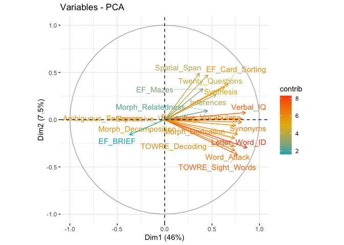

```r
#line below runs a simple PCA with a component for each variable.
viz_pca <- prcomp(scaled_data_pca, center = TRUE,scale. = TRUE)

#Graph of variables. Positive correlated variables point to the same side of the plot. Negative correlated variables point to opposite sides of the graph.
fviz_pca_var(viz_pca,
             col.var = "contrib", # Color by contributions to the PC
             gradient.cols = c("#00AFBB", "#E7B800", "#FC4E07"),
             repel = TRUE #Avoid overlapping text if possible
             )
```

## 3.5 Bartlett’s Test

The Bartlett’s test was run to determine if the R-matrix was an identity matrix. A significant p-value, < 0.05 indicated that the matrix was not an identity matrix.

```r
cortest.bartlett(scaled_data_pca, 223) #223 equals sample size
```

```
## R was not square, finding R from data
```

```
## $chisq
## [1] 2702.705
##
## $p.value
## [1] 0
##
## $df
## [1] 171
```

```r
# p value below .05, so it is not an identity matrix. This is good.
```

## 3.6 KMO

The Kaiser-Meyer-Olkin (KMO) index is a Measure of Sampling Adequacy (MSA). It was run to measure sampling adequacy for each variable in the model and for the complete model. All statistics were .8 or above, indicating that there was sufficient shared variance among variables.

```r
KMO(scaled_data_pca)
```

```
## Kaiser-Meyer-Olkin factor adequacy
## Call: KMO(r = scaled_data_pca)
## Overall MSA =  0.92
## MSA for each item =
##              EF_BRIEF             Verbal_IQ        Letter_Word_ID
##                  0.91                  0.95                  0.93
##           Word_Attack             Synthesis        TOWRE_Decoding
##                  0.89                  0.95                  0.91
##     TOWRE_Sight_Words Expressive_Vocabulary  Receptive_Vocabulary
##                  0.87                  0.93                  0.94
##              Synonyms   Ambiguous_Sentences            Inferences
##                  0.95                  0.98                  0.93
##      Morph_Derivation   Morph_Decomposition     Morph_Relatedness
##                  0.89                  0.86                  0.95
##          Spatial_Span      Twenty_Questions              EF_Mazes
##                  0.82                  0.92                  0.81
##       EF_Card_Sorting
##                  0.94
```

## 3.7 Base PCA & Residuals

A base PCA was run with all 19 available variables to determine eigenvalues or sums of squared loadings. These provided the amount of variance each factor explained. There were 3 sums of squared loadings that were greater than 1, meeting Kaiser’s criterion for inclusion as a component. Then a scree plot was created to visually see the eigenvalues plotted against the number of factors. There was a striking “elbow” at 2 factors and a much smaller one at 3 factors, indicating that 2 or 3 factors were best for the variables provided. From there, another priniciple component analysis was run using 3 factors. 3 was chosen because it was aligned with the sum of squared loadings and with theory about these measures.

### 3.7.1 Base PCA

```r
pca_base <- principal(scaled_data_pca, nfactors = 19, rotate = "none") #base pca with all 19 variables

pca_base #results= 3 SS with values higher than 1, so possibly 3 factors here based on that info alone
```

```
## Principal Components Analysis
## Call: principal(r = scaled_data_pca, nfactors = 19, rotate = "none")
## Standardized loadings (pattern matrix) based upon correlation matrix
##                         PC1   PC2   PC3   PC4   PC5   PC6   PC7   PC8   PC9
## EF_BRIEF              -0.37 -0.16  0.28 -0.01  0.79  0.22  0.09  0.19  0.15
## Verbal_IQ              0.85  0.07  0.14 -0.18 -0.03 -0.02 -0.10  0.01  0.02
## Letter_Word_ID         0.87 -0.30 -0.08  0.01  0.00  0.09 -0.01  0.08  0.00
## Word_Attack            0.74 -0.33 -0.32  0.16 -0.13  0.07 -0.01  0.14  0.08
## Synthesis              0.63  0.34  0.16  0.16 -0.06  0.03 -0.04  0.13  0.48
## TOWRE_Decoding         0.73 -0.28 -0.26 -0.03  0.04  0.26  0.08 -0.01 -0.01
## TOWRE_Sight_Words      0.77 -0.37 -0.32  0.00 -0.08  0.23  0.04  0.06  0.07
## Expressive_Vocabulary  0.75  0.00  0.12 -0.38  0.08 -0.10 -0.13  0.21 -0.13
## Receptive_Vocabulary   0.82  0.01  0.08 -0.30  0.10 -0.04 -0.07 -0.05 -0.17
## Synonyms               0.81 -0.03  0.12 -0.23  0.02 -0.17 -0.05  0.01  0.02
## Ambiguous_Sentences    0.75 -0.06  0.15 -0.15  0.09 -0.12 -0.07  0.01  0.15
## Inferences             0.54  0.27  0.24  0.00  0.04  0.58 -0.09 -0.40 -0.17
## Morph_Derivation       0.77 -0.15  0.21  0.28  0.11 -0.23  0.18 -0.26  0.05
## Morph_Decomposition    0.74 -0.20  0.19  0.37  0.08 -0.20  0.24 -0.23 -0.04
## Morph_Relatedness      0.45  0.09  0.33  0.56 -0.05  0.05 -0.42  0.32 -0.23
## Spatial_Span           0.37  0.49 -0.54  0.09  0.17  0.03 -0.25 -0.15  0.23
## Twenty_Questions       0.46  0.47  0.12  0.01 -0.20  0.21  0.57  0.30 -0.06
## EF_Mazes               0.41  0.33 -0.55  0.16  0.40 -0.18  0.12  0.09 -0.31
## EF_Card_Sorting        0.67  0.38  0.07 -0.12 -0.01 -0.16  0.05 -0.08 -0.01
##                        PC10  PC11  PC12  PC13  PC14  PC15  PC16  PC17  PC18
## EF_BRIEF               0.05  0.07  0.11  0.05  0.03 -0.02  0.01 -0.01  0.02
## Verbal_IQ              0.03  0.00  0.07  0.06 -0.07 -0.33 -0.27  0.01 -0.02
## Letter_Word_ID         0.07 -0.01  0.17 -0.09 -0.06  0.05 -0.03 -0.11 -0.22
## Word_Attack            0.09  0.02  0.23 -0.21  0.04 -0.09  0.05 -0.04  0.22
## Synthesis             -0.06 -0.40 -0.04 -0.03 -0.05  0.01  0.07  0.00 -0.02
## TOWRE_Decoding         0.00 -0.08 -0.29  0.34 -0.11  0.03 -0.05 -0.05  0.10
## TOWRE_Sight_Words      0.06  0.04  0.01  0.06  0.09  0.06  0.05  0.16 -0.11
## Expressive_Vocabulary -0.18  0.05  0.05 -0.08 -0.33  0.14  0.06  0.03  0.05
## Receptive_Vocabulary  -0.13 -0.08 -0.04  0.07  0.16 -0.21  0.29 -0.02 -0.02
## Synonyms              -0.23 -0.05  0.11  0.07  0.30  0.21 -0.16 -0.01  0.05
## Ambiguous_Sentences    0.23  0.21 -0.40 -0.27  0.08  0.03 -0.02 -0.03  0.00
## Inferences             0.01 -0.08  0.04 -0.18  0.00  0.07 -0.03  0.01  0.03
## Morph_Derivation      -0.07  0.09  0.02  0.00 -0.08 -0.02  0.01  0.24  0.01
## Morph_Decomposition   -0.13  0.03  0.00  0.02 -0.05  0.01  0.03 -0.20 -0.01
## Morph_Relatedness      0.02  0.09 -0.06  0.11  0.05  0.02  0.01  0.02  0.00
## Spatial_Span          -0.19  0.33  0.04  0.07 -0.02  0.00  0.03 -0.03 -0.02
```

[output cut: 29 more lines]

```
## Cumulative Proportion 0.46 0.54 0.60 0.66 0.70 0.75 0.78 0.82 0.85 0.87 0.90
##                       PC12 PC13 PC14 PC15 PC16 PC17 PC18 PC19
## SS loadings           0.40 0.38 0.28 0.25 0.21 0.14 0.13 0.11
## Proportion Var        0.02 0.02 0.01 0.01 0.01 0.01 0.01 0.01
## Cumulative Var        0.92 0.94 0.96 0.97 0.98 0.99 0.99 1.00
## Proportion Explained  0.02 0.02 0.01 0.01 0.01 0.01 0.01 0.01
## Cumulative Proportion 0.92 0.94 0.96 0.97 0.98 0.99 0.99 1.00
##
## Mean item complexity =  3.3
## Test of the hypothesis that 19 components are sufficient.
##
## The root mean square of the residuals (RMSR) is  0
##  with the empirical chi square  0  with prob <  NA
##
## Fit based upon off diagonal values = 1
```

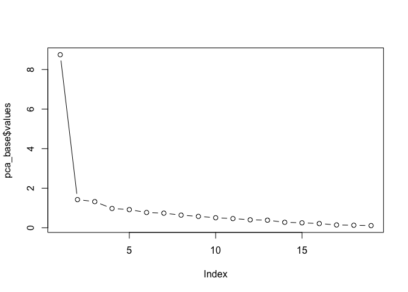

```r
plot(pca_base$values, type = "b")#makes a scree plot using eigen values stored in pca_base$values,
```

```r
#plots the eigenvalues (y) against the factor number (x)
#type = 'b' both gives you a line and points on the same graph
#check for how many variables it indicates by the "elbow" seen visually in graph
# big elbow at 2
```

### 3.7.2 Residuals Check

A PCA was run with the 3 factors decided in the previous step. A correlation matrix was created from the correlations of the scaled scores. Then the residuals of that correlation matrix were compared to the residuals of the PCA factor loadings. A histogram was called to check for a normal distribution of residuals. The residuals were relatively normal, with what looked to be a few outliers.

```r
pca_resid <- principal(scaled_data_pca, nfactors = 3, rotate = "none")
pca_resid #results. 3 looks ok. 2 may be better based on the picture but I want 3 to fit the research question.
```

```
## Principal Components Analysis
## Call: principal(r = scaled_data_pca, nfactors = 3, rotate = "none")
## Standardized loadings (pattern matrix) based upon correlation matrix
##                         PC1   PC2   PC3   h2   u2 com
## EF_BRIEF              -0.37 -0.16  0.28 0.24 0.76 2.3
## Verbal_IQ              0.85  0.07  0.14 0.76 0.24 1.1
## Letter_Word_ID         0.87 -0.30 -0.08 0.85 0.15 1.2
## Word_Attack            0.74 -0.33 -0.32 0.76 0.24 1.8
## Synthesis              0.63  0.34  0.16 0.55 0.45 1.7
## TOWRE_Decoding         0.73 -0.28 -0.26 0.68 0.32 1.6
## TOWRE_Sight_Words      0.77 -0.37 -0.32 0.83 0.17 1.8
## Expressive_Vocabulary  0.75  0.00  0.12 0.58 0.42 1.1
## Receptive_Vocabulary   0.82  0.01  0.08 0.67 0.33 1.0
## Synonyms               0.81 -0.03  0.12 0.67 0.33 1.0
## Ambiguous_Sentences    0.75 -0.06  0.15 0.59 0.41 1.1
## Inferences             0.54  0.27  0.24 0.42 0.58 1.9
## Morph_Derivation       0.77 -0.15  0.21 0.66 0.34 1.2
## Morph_Decomposition    0.74 -0.20  0.19 0.62 0.38 1.3
## Morph_Relatedness      0.45  0.09  0.33 0.32 0.68 1.9
## Spatial_Span           0.37  0.49 -0.54 0.67 0.33 2.8
## Twenty_Questions       0.46  0.47  0.12 0.44 0.56 2.1
## EF_Mazes               0.41  0.33 -0.55 0.57 0.43 2.5
## EF_Card_Sorting        0.67  0.38  0.07 0.60 0.40 1.6
##
##                        PC1  PC2  PC3
## SS loadings           8.75 1.42 1.32
## Proportion Var        0.46 0.07 0.07
## Cumulative Var        0.46 0.54 0.60
## Proportion Explained  0.76 0.12 0.12
## Cumulative Proportion 0.76 0.88 1.00
##
## Mean item complexity =  1.6
## Test of the hypothesis that 3 components are sufficient.
##
## The root mean square of the residuals (RMSR) is  0.06
##  with the empirical chi square  284.42  with prob <  5.8e-16
##
## Fit based upon off diagonal values = 0.98
```

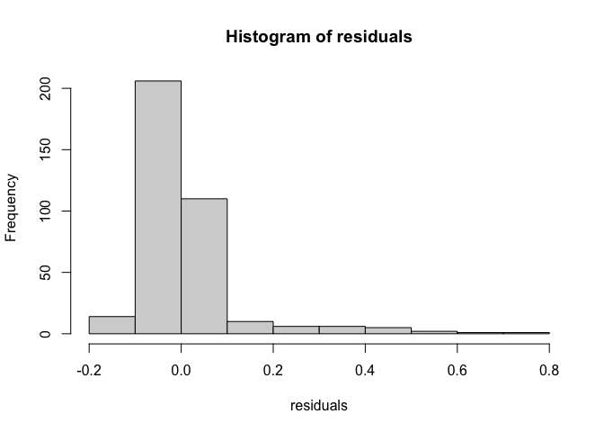

```r
corMatrix<-cor(scaled_data_pca)#require correlation matrix for final data
#corMatrix

residuals<-factor.residuals(corMatrix, pca_resid$loadings)#create an object from the correlation matrix and the pca loading. Call it residuals. It will contain the factor residuals

hist(residuals) #are the residuals normally distributed? that is an assumption of a PCA is that it is normally distributed.
```

## 3.8 Final PCA

```r
pca_final <- principal(scaled_data_pca, nfactors = 3, rotate = "promax") #Since factors should be related, use oblique technique (promax)
pca_final #results.
```

```
## Principal Components Analysis
## Call: principal(r = scaled_data_pca, nfactors = 3, rotate = "promax")
## Standardized loadings (pattern matrix) based upon correlation matrix
##                         RC2   RC1   RC3   h2   u2 com
## EF_BRIEF              -0.10 -0.19 -0.36 0.24 0.76 1.7
## Verbal_IQ              0.67  0.27  0.01 0.76 0.24 1.3
## Letter_Word_ID         0.20  0.79 -0.02 0.85 0.15 1.1
## Word_Attack           -0.10  0.90  0.14 0.76 0.24 1.1
## Synthesis              0.77 -0.12  0.14 0.55 0.45 1.1
## TOWRE_Decoding        -0.01  0.81  0.12 0.68 0.32 1.0
## TOWRE_Sight_Words     -0.11  0.95  0.11 0.83 0.17 1.1
## Expressive_Vocabulary  0.54  0.31 -0.02 0.58 0.42 1.6
## Receptive_Vocabulary   0.54  0.36  0.02 0.67 0.33 1.7
## Synonyms               0.55  0.37 -0.04 0.67 0.33 1.8
## Ambiguous_Sentences    0.51  0.35 -0.09 0.59 0.41 1.9
## Inferences             0.72 -0.13  0.02 0.42 0.58 1.1
## Morph_Derivation       0.50  0.42 -0.19 0.66 0.34 2.3
## Morph_Decomposition    0.43  0.46 -0.20 0.62 0.38 2.4
## Morph_Relatedness      0.61 -0.06 -0.17 0.32 0.68 1.2
## Spatial_Span           0.15  0.01  0.77 0.67 0.33 1.1
## Twenty_Questions       0.73 -0.31  0.23 0.44 0.56 1.6
## EF_Mazes               0.04  0.20  0.68 0.57 0.43 1.2
## EF_Card_Sorting        0.74 -0.08  0.23 0.60 0.40 1.2
##
##                        RC2  RC1  RC3
## SS loadings           5.24 4.69 1.57
## Proportion Var        0.28 0.25 0.08
## Cumulative Var        0.28 0.52 0.60
## Proportion Explained  0.46 0.41 0.14
## Cumulative Proportion 0.46 0.86 1.00
##
##  With component correlations of
##      RC2  RC1  RC3
## RC2 1.00 0.61 0.19
## RC1 0.61 1.00 0.16
## RC3 0.19 0.16 1.00
##
## Mean item complexity =  1.4
## Test of the hypothesis that 3 components are sufficient.
##
## The root mean square of the residuals (RMSR) is  0.06
##  with the empirical chi square  284.42  with prob <  5.8e-16
##
## Fit based upon off diagonal values = 0.98
```

```r
print.psych(pca_final, cut = 0.3, sort = TRUE)#makes results easier to read by only including loadings over .3 (think of medium correlation)
```

```
## Principal Components Analysis
## Call: principal(r = scaled_data_pca, nfactors = 3, rotate = "promax")
## Standardized loadings (pattern matrix) based upon correlation matrix
##                       item   RC2   RC1   RC3   h2   u2 com
## Synthesis                5  0.77             0.55 0.45 1.1
## EF_Card_Sorting         19  0.74             0.60 0.40 1.2
## Twenty_Questions        17  0.73 -0.31       0.44 0.56 1.6
## Inferences              12  0.72             0.42 0.58 1.1
## Verbal_IQ                2  0.67             0.76 0.24 1.3
## Morph_Relatedness       15  0.61             0.32 0.68 1.2
## Synonyms                10  0.55  0.37       0.67 0.33 1.8
## Receptive_Vocabulary     9  0.54  0.36       0.67 0.33 1.7
## Expressive_Vocabulary    8  0.54  0.31       0.58 0.42 1.6
## Ambiguous_Sentences     11  0.51  0.35       0.59 0.41 1.9
## Morph_Derivation        13  0.50  0.42       0.66 0.34 2.3
## TOWRE_Sight_Words        7        0.95       0.83 0.17 1.1
## Word_Attack              4        0.90       0.76 0.24 1.1
## TOWRE_Decoding           6        0.81       0.68 0.32 1.0
## Letter_Word_ID           3        0.79       0.85 0.15 1.1
## Morph_Decomposition     14  0.43  0.46       0.62 0.38 2.4
## Spatial_Span            16              0.77 0.67 0.33 1.1
## EF_Mazes                18              0.68 0.57 0.43 1.2
## EF_BRIEF                 1             -0.36 0.24 0.76 1.7
##
##                        RC2  RC1  RC3
## SS loadings           5.24 4.69 1.57
## Proportion Var        0.28 0.25 0.08
## Cumulative Var        0.28 0.52 0.60
## Proportion Explained  0.46 0.41 0.14
## Cumulative Proportion 0.46 0.86 1.00
##
##  With component correlations of
##      RC2  RC1  RC3
## RC2 1.00 0.61 0.19
## RC1 0.61 1.00 0.16
## RC3 0.19 0.16 1.00
##
## Mean item complexity =  1.4
## Test of the hypothesis that 3 components are sufficient.
##
## The root mean square of the residuals (RMSR) is  0.06
##  with the empirical chi square  284.42  with prob <  5.8e-16
##
## Fit based upon off diagonal values = 0.98
```

### 3.8.1 Final PCA Plot

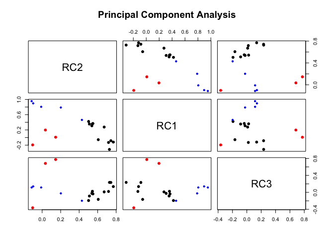

```r
plot(pca_final) #The far right on each box shows where the component's observations cluster compared to each other cluster.
```

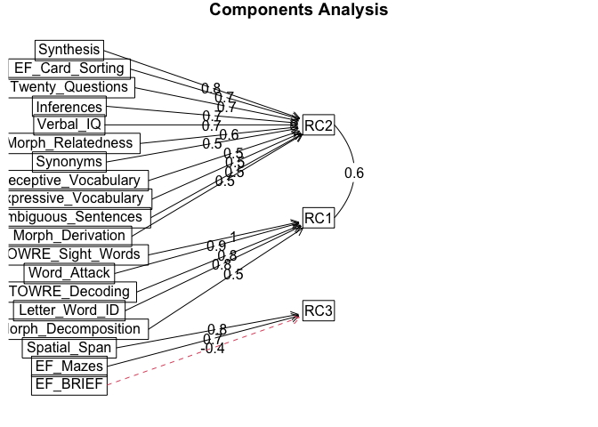

```r
#component 2 is black
#component 1 is blue
#component 3 is red

fa.diagram(pca_final)# shows the factor analysis diagram, including correlations of measures to components and components with each other.
```

## Component Names Components were named based on what primary concept or skill was represented with the measures that loaded onto the component.

**Component** 1: *Decoding*

**Component** 2: *Language*

**Component** 3: *Executive Function*

## 3.9 Factor Scores

The factor scores for each observation were collected from the final PCA. The columns were then renamed to reflect the new component names. Finally, the factor scores tibble and the tibble with all vairables and the outcome variable were combined to be used in later analysis.

```r
pca_final_scores <- as.data.frame(pca_final$scores) #pca scores for each particpant on each factor. You can use these in subsequent analyses
pca_final_scores
```

```
##              RC2          RC1          RC3
## 1   -0.169741257 -1.216369015  0.143518744
## 2    0.017658391 -0.386907583 -0.105871998
## 3   -2.297268485 -3.266200715  0.511689163
## 4   -1.184197814  0.255037196  2.194484848
## 5    0.943978116  0.037114237  1.172909818
## 6    0.743181131 -1.280150507  0.724650638
## 7   -0.261571263 -0.321927634 -0.250907852
## 8    0.186631341 -1.262853945 -0.324283239
## 9    0.368009786  0.831300047  0.806797981
## 10  -0.912458633 -1.229901242 -1.474531542
## 11  -2.585385999  0.280755997 -1.346380781
## 12  -0.639118118 -0.525465023  0.309536454
## 13   1.908713235  0.440052854  0.416564522
## 14   0.056621900 -0.960011752  0.261700313
```

[output cut: 209 more lines]

```r
pca_final_scores <- pca_final_scores %>%
  rename(Decoding = RC1, Language = RC2, Executive_Function = RC3)#rename columns

RCV_pca_4 <- RCV_pca_2 %>%
  select(-3) # Made a tibble that didn't have WASI but did have WJ comprehension

final_data <- cbind(RCV_pca_4, pca_final_scores)#combine this dataframe with earlier dataframe (RCV_pca_4)
str(final_data)
```

```
## 'data.frame':    223 obs. of  23 variables:
##  $ WJ_Reading_Comprehension: num  95 88 58 88 107 99 102 89 105 80 ...
##  $ EF_BRIEF                : num  76 49 50 50 39 72 63 43 62 76 ...
##  $ Verbal_IQ               : num  99 105 80 93 134 110 102 110 112 98 ...
##  $ Letter_Word_ID          : num  94 104 61 98 100 92 98 87 117 80 ...
##  $ Word_Attack             : num  86 89 68 98 88 84 96 84 104 89 ...
##  $ Synthesis               : num  103 86 85 90 102 124 123 92 106 89 ...
##  $ TOWRE_Decoding          : num  97 97 70 114 107 89 107 87 110 80 ...
##  $ TOWRE_Sight_Words       : num  77 94 67 117 92 67 90 82 120 75 ...
##  $ Expressive_Vocabulary   : num  7 8 3 7 12 10 6 7 11 6 ...
##  $ Receptive_Vocabulary    : num  12 12 4 12 14 10 10 11 14 11 ...
##  $ Synonyms                : num  7 13 3 10 14 11 11 10 14 11 ...
##  $ Ambiguous_Sentences     : num  6 8 5 10 12 13 7 6 11 9 ...
##  $ Inferences              : num  10 11 7 7 13 8 6 12 7 4 ...
##  $ Morph_Derivation        : num  21 24 3 18 22 23 19 19 24 16 ...
##  $ Morph_Decomposition     : num  23 24 8 20 27 25 27 25 26 24 ...
##  $ Morph_Relatedness       : num  10 9 8 5 9 10 10 10 9 9 ...
##  $ Spatial_Span            : num  12 14 9 14 16 15 10 7 17 8 ...
##  $ Twenty_Questions        : num  12 13 8 13 8 11 8 12 13 9 ...
##  $ EF_Mazes                : num  13 7 8 15 13 15 11 11 10 8 ...
##  $ EF_Card_Sorting         : num  9 8 7 10 14 13 11 12 12 7 ...
##  $ Language                : num  -0.1697 0.0177 -2.2973 -1.1842 0.944 ...
##  $ Decoding                : num  -1.2164 -0.3869 -3.2662 0.255 0.0371 ...
##  $ Executive_Function      : num  0.144 -0.106 0.512 2.194 1.173 ...
```

```r
write.csv(final_data,"pca_scores_final_df.csv", row.names=FALSE) #create a csv of the final data
```

# 4 Data Modeling

To answer research question 2, the data needed to be modeled with reading comprehension as the outcome variable and the three components from the PCA as the predictor variables. The regression model was the result of a multicollinearity check, 10-fold cross-validation and stepwise feature selection.

## 4.1 Multicollinearity Check

Correlations were run on all components of interest to check for multicollinearity. This made sure components that were too similar were not included in cross validation and feature selection. No component was correlated with another component above .7, so all three components were kept. Visualization matrices were created using corrplot.

```r
RCV_reg <- read_csv("pca_scores_final_df.csv") %>%
  select(1,21:23)
cor(RCV_reg)
```

```
##                          WJ_Reading_Comprehension  Language  Decoding
## WJ_Reading_Comprehension                1.0000000 0.7429550 0.7287937
## Language                                0.7429550 1.0000000 0.6132552
## Decoding                                0.7287937 0.6132552 1.0000000
## Executive_Function                      0.1876390 0.1926639 0.1649674
##                          Executive_Function
## WJ_Reading_Comprehension          0.1876390
## Language                          0.1926639
## Decoding                          0.1649674
## Executive_Function                1.0000000
```

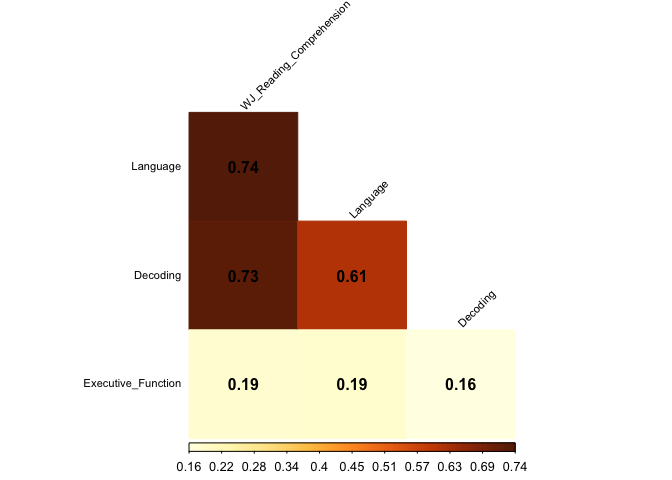

```r
library(corrplot) #install the library that allows you to make pretty correlation charts
cor_matrix <- (cor(RCV_reg)) #create a data set of the correlations of all RCV data to use in the pretty correlation charts

corrplot(cor_matrix,
         type="lower", #put color strength on bottom
         tl.pos = "ld", #Character or logical, position of text labels, 'ld'(default if type=='lower') means left and diagonal,
         tl.cex = .7, #Numeric, for the size of text label (variable names).
         method="color",
         addCoef.col="black",
         diag=FALSE,
         tl.col="black", #The color of text label.
         tl.srt=45, #Numeric, for text label string rotation in degrees, see text
         is.corr = FALSE, #if you include correlation matrix
         #order = "hclust", #order results by strength
         #col=gray.colors(100), #in case you want it in gray...
         number.digits = 2) #number of digits after decimal
```

```r
#all correlations were the expected direction.
```

## 4.2 Cross Validation & Feature Selection

### 4.2.1 Cross Validation Set-up

```r
library(caret) # library needed for cross validation and feature selection
set.seed(123)#set seed for replication of cross-validation at later time

# Set up repeated 10-fold cross-validation
train_control <- trainControl(method = "cv", number = 10)
#method = cross validation, number = ten times (10 fold cross-validation)
```

### 4.2.2 Feature Selection

```r
#the LM model used
lm_cv10_step <- train(WJ_Reading_Comprehension ~ .,
                data = RCV_reg,
                method = "leapSeq", #stepwise selection
                           tuneGrid = data.frame(nvmax = 1:3), #using 1-7 predictors that we still have after multicollinearity check
                           trControl = train_control)

#the model
summary(lm_cv10_step)
```

```
## Subset selection object
## 3 Variables  (and intercept)
##                    Forced in Forced out
## Language               FALSE      FALSE
## Decoding               FALSE      FALSE
## Executive_Function     FALSE      FALSE
## 1 subsets of each size up to 2
## Selection Algorithm: 'sequential replacement'
##          Language Decoding Executive_Function
## 1  ( 1 ) "*"      " "      " "
## 2  ( 1 ) "*"      "*"      " "
```

### 4.2.3 Final Model Selection

The 10-fold cross validation and the stepwise feature selection resulted in a best tuned model with 2 predictors. The results showed that this model had the lowest RMSE and highest R-squared. This model’s coefficients for each predictor were checked for suppression effects. All coefficients directionally aligned with the correlations from earlier steps, showing no suppression effects. The final linear regression model was run with reading comprehension predicted by the two predictors selected in machine learning. This provided the necessary statistical outputs (t-values, p-values, etc.) that are useful and interpretable across fields.

```r
#best tuned model
lm_cv10_step$bestTune #2 predictors
```

```
##   nvmax
## 2     2
```

```r
lm_cv10_step$results #confirm that model with 2 predictors has the lowest RMSE and highest Rsquared
```

```
##   nvmax     RMSE  Rsquared      MAE   RMSESD RsquaredSD     MAESD
## 1     1 8.846453 0.5700910 6.869538 1.532543 0.11943252 0.9950434
## 2     2 7.695948 0.6959392 5.932097 1.069906 0.07235997 0.7959907
## 3     3 7.741037 0.6926632 5.947371 1.058040 0.06933355 0.8173846
```

```r
#co-efficients for model using 2 variables
coef(lm_cv10_step$finalModel, 2) #check for any suppression effects. all match the correlation direction
```

```
## (Intercept)    Language    Decoding
##   99.874439    6.311715    5.824597
```

```r
#final linear model
final_lm <- lm(WJ_Reading_Comprehension~ Decoding + Language, data = RCV_reg) #include the 2 predictors from feature selection
summary(final_lm) # this shows the statistical info for the model chosen through cv and feature selection
```

```
##
## Call:
## lm(formula = WJ_Reading_Comprehension ~ Decoding + Language,
##     data = RCV_reg)
##
## Residuals:
##     Min      1Q  Median      3Q     Max
## -31.646  -4.118   0.351   5.053  17.818
##
## Coefficients:
##             Estimate Std. Error t value Pr(>|t|)
## (Intercept)  99.8744     0.5128 194.749   <2e-16 ***
## Decoding      5.8246     0.6507   8.951   <2e-16 ***
## Language      6.3117     0.6507   9.700   <2e-16 ***
## ---
## Signif. codes:  0 '***' 0.001 '**' 0.01 '*' 0.05 '.' 0.1 ' ' 1
##
## Residual standard error: 7.658 on 220 degrees of freedom
## Multiple R-squared:  0.6716, Adjusted R-squared:  0.6686
## F-statistic: 224.9 on 2 and 220 DF,  p-value: < 2.2e-16
```

## 4.3 Visualization

A visualization of the residuals of the final linear model was created using ggplot. The actual values for reading comprehension came from the original data while the predicted values came from the linear regression model.

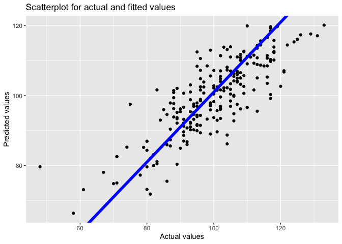

```r
library(ggplot2)
actual <- RCV_reg$WJ_Reading_Comprehension
fitted <- unname(final_lm$fitted.values) #would have been a named number vector if unname not used
#grab up the fitted values from the regression model

act_fit <- cbind.data.frame(actual, fitted) #cbind binds the two vectors into a dataframe

ggplot(act_fit, aes(x = actual, y = fitted)) +
  geom_point() +
  xlab("Actual values") +
  ylab("Predicted values") +
  ggtitle("Scatterplot for actual and fitted values") +
  geom_abline(intercept = 1,
              slope = 1,
              color = "blue",
              linewidth = 2)
```

# 5 Discussion

## 5.2 Research Question 2

# 6 References

Aboud, K.S., Barquero, L.A., & Cutting, L.E. (2018). Prefrontal mediation of the reading network predicts intervention response in dyslexia. Cortex, 101, 96–106. https://doi-org.proxy.library.vanderbilt.edu/10.1016/j.cortex

Cutting LE, Bailey SK, Barquero LA, & Aboud K (2015). Neurobiological bases of word recognition and reading comprehension In Connor CM & McCardle P (Eds.), Advances in reading intervention: Research to practice to research (pp. 73–84). Baltimore, MD: Brookes Publishing.

Gough, P. B., & Tunmer, W. E. (1986). Decoding, reading, and reading disability. Remedial and special education, 7(1), 6-10. https://doi.org/10.1177/074193258600700104

Locascio, G., Mahone, E. M., Eason, S. H., & Cutting, L. E. (2010). Executive dysfunction among children with reading comprehension deficits. Journal of Learning Disabilities, 43(5), 441-454. https://doi.org/10.1177/0022219409355476

Rabiner, D. L., Godwin, J., & Dodge, K. A. (2016). Predicting academic achievement and attainment: The contribution of early academic skills, attention difficulties, and social competence. School Psychology Review, 45(2), 250-267.https://doi.org/10.17105/SPR45-2.250-267